# FEML in FEniCSx — 노트북 해설

Missing Physics Discovery를 FEniCSx + PyTorch로 구현하기 · 코드 해부와 PEMFC 이식 설계

PSE Lab

# Part 0. 좌표 잡기

## 0.1 이 노트북이 하는 일

**FEML**(Finite Element-based Machine Learning) 논문 — Farsi, Bouziani & Ham (2026) — 의 두 사례를, **Firedrake가 아니라 FEniCSx + PyTorch**로 재현한 구현체다.

원논문의 프레임워크는 한 줄로 요약된다:

$$F(u_\theta,\ \mathcal G_\theta(u_\theta);\ v) = 0 \qquad \forall v \in U_h$$

- $F$ — **알려진 물리**. 약형식 잔차로 그대로 둔다.
- $\mathcal G_\theta$ — **모르는 관계**(missing physics). 학습 연산자로 바꿔 잔차 **안에** 끼워 넣는다.
- 손실 $\mathcal L(u_\theta, u^{obs})$ — $\mathcal G_\theta$의 직접 관측이 아니라 **PDE 해**와 관측의 차이로 정의한다.

핵심은 마지막 줄이다. 학습시키려는 대상(응력, 열전도율, 유효확산계수)은 대개 **직접 측정할 수 없다**. 측정 가능한 것은 그 결과(변위, 온도장)뿐이다. 그래서 PDE 솔버를 학습 루프 안에 집어넣고, 솔버를 **관통해서** 미분해야 한다.

## 0.2 원논문과의 대응

|  | FEML 논문 | 이 노트북 |
| --- | --- | --- |
| PDE 프레임워크 | Firedrake | **FEniCSx / DOLFINx 0.10** |
| 미분 경로 | pyadjoint 계열 자동 adjoint | **손코딩 discrete adjoint** |
| ML 프레임워크 | PyTorch / JAX | PyTorch (CPU) |
| 연산자 표현 | SPON (encode-process-decode) | quadrature 공간 MLP |
| 사례 A | §1.3 과도 열전도 $k(T)$ | **Case 4** (정상상태로 축소) |
| 사례 B | §1.2 구성법칙 $\sigma=\mathcal G_\theta(\varepsilon)$ | **Case 1** $E(I_1)$ |
| 사례 C | §1.2.3 zero-shot 전이 (2D→3D) | 미구현 (Case 5로 예고만) |

**가장 중요한 차이**: 원논문은 성숙한 adjoint 인프라 위에 서 있고, 이 노트북은 그것을 **PETSc 수준에서 직접 조립**했다. 이 파일 전체가 사실상 “그 조립 과정”의 기록이다.

## 0.3 결과 요약

| Case | 학습 대상 | 오차 | 시간 |
| --- | --- | --- | --- |
| **Case 4** | 비선형 열전도율 $k(T)$ | **0.7%** | 187 s |
| **Case 1** | 비선형 구성법칙 $E(I_1)$ | **9.0%** | 8,666 s (2.4 h) |

두 사례 모두 **합성 데이터**(알려진 법칙으로 생성 후 잡음 주입)로 학습했다. 실측 데이터는 없다.

## 0.4 노트북 23셀 → 4블록

```
Cell 0-1    [md]        제목 / 섹션
Cell 2      [code]      DOLFINx 0.10 설치 (micromamba)
Cell 3-4    [md+code]   FEML extras: external-operator + PyTorch
Cell 5-7    [md+code]   %%fenicsx 매직 등록 및 검증
────────────────────────────────────────────────
Cell 8-9    [md]        Case 4 문제 정의
Cell 10     [code]      Case 4 전체 (데이터생성 + 학습 + 평가)   ← 314줄
Cell 11-12  [md+code]   Case 4 결과 플롯
────────────────────────────────────────────────
Cell 13-14  [md]        Case 1 문제 정의
Cell 15     [code]      Case 1 GT 데이터 생성 (Cell 7a)          ← 230줄
Cell 16-17  [md+code]   Case 1 학습 (Cell 7b)                   ← 531줄
Cell 18-19  [md+code]   Case 1 결과 플롯
────────────────────────────────────────────────
Cell 20-22  [md+code]   결과 zip 다운로드 / 요약
```

실질적 내용은 **Cell 10, 15, 17** 세 개(합 1,075줄)에 전부 들어 있다. 이 슬라이드도 그 셋에 분량을 집중한다.

# Part 1. 실행 환경 (Cell 2, 4, 6, 7)

## 1.1 DOLFINx 0.10 + micromamba

```python
REPO_URL = 'https://github.com/SeoulTechPSE/fenicsx-colab.git'
N_PROC = 1
with open('/root/hostfile','w') as f:
    f.write(f'localhost slots={N_PROC}\n')
os.environ['OMPI_MCA_rmaps_default_mapping_policy'] = 'slot:OVERSUBSCRIBE'
os.environ['PRTE_MCA_rmaps_default_mapping_policy'] = 'slot:OVERSUBSCRIBE'
%run {REPO_DIR/'setup_fenicsx.py'} --version 0.10
```

**PEMFC 노트북과 다른 점 두 가지:**

- **버전 0.10** (PEMFC는 0.11). `dolfinx-external-operator`가 0.10.0에 맞춰 pin되어 있어 짝을 맞춘 것으로 보인다.
- **`N_PROC = 1`** (PEMFC는 4). 학습 루프가 PyTorch와 얽혀 있어 MPI 병렬을 쓰지 않는다 — adjoint 조립과 `backward()`가 전부 단일 프로세스 가정 위에서 돌아간다.

Drive를 패키지 캐시로 쓰므로 첫 실행 5–10분, 이후 30초.

## 1.2 `env_pip` — micromamba run 우회

```python
MAMBA  = '/content/micromamba/bin/micromamba'
PYTHON = f'/content/micromamba/envs/fenicsx/bin/python'

def env_pip(*pkgs, no_deps=False, extra_index=None):
    """Use conda env python -m pip directly (bypasses micromamba run)."""
    cmd = [PYTHON, '-m', 'pip', 'install', '--quiet'] + list(pkgs)
    ...
```

**문제**: `micromamba run -n fenicsx pip install ...` 방식은 환경 활성화 과정에서 실패하는 경우가 있다.

**해결**: 그 환경의 python 실행파일을 **절대경로로 직접 호출**해 `-m pip`를 돌린다. micromamba의 활성화 계층을 완전히 건너뛴다.

부수적으로 `ensurepip` 폴백도 들어 있다 — conda-forge 환경에 pip이 없을 수 있기 때문(실제로 출력 로그에 `pip not found -> installing via ensurepip...`가 찍혔다).

## 1.3 `--no-deps`로 설치하는 이유

```python
ok = env_pip('dolfinx-external-operator==0.10.0', no_deps=True)
if not ok:
    ok = env_pip('git+https://github.com/a-latyshev/dolfinx-external-operator.git',
                 no_deps=True)
```

`dolfinx-external-operator`는 순수 파이썬 패키지지만, 의존성 목록에 DOLFINx와 UFL이 들어 있다. `--no-deps` 없이 설치하면 **pip이 conda-forge로 설치된 DOLFINx를 덮어쓰려 시도**해 환경이 깨진다.

이미 conda 환경에 정상 설치된 DOLFINx/UFL이 있으므로, 의존성 해결을 건너뛰고 순수 파이썬 코드만 얹는다. PyPI 실패 시 GitHub 소스로 폴백하는 이중 경로도 준비되어 있다.

## 1.4 “DOLFINx는 `%%fenicsx` 안에서만” — GLIBCXX 제약

Cell 2 마지막 출력:

> `(DOLFINx must be imported inside %%fenicsx cells only — GLIBCXX version constraint)`

**이유**: Colab 호스트의 시스템 파이썬과 micromamba 환경은 **서로 다른 libstdc++ 버전**에 링크되어 있다. 호스트 파이썬에서 conda 환경의 DOLFINx를 import하면 `GLIBCXX_3.4.xx not found` 류의 심볼 오류가 난다.

`%%fenicsx` 매직은 셀 내용을 **conda 환경의 python으로 실행되는 별도 subprocess**에 넘긴다. 그 안에서는 라이브러리 버전이 일관되므로 문제가 없다.

**대가**: 그 subprocess에는 `google.colab`이 없다. 그래서 Drive 마운트는 반드시 `%%fenicsx` 바깥의 평범한 셀에서 먼저 해야 한다 — PEMFC 노트북과 완전히 같은 제약이다.

## 1.5 환경 검증 (Cell 5)

```python
%%fenicsx
import dolfinx, sys
from dolfinx_external_operator import FEMExternalOperator
import torch
```

실행 출력:

```
Python  : 3.14.6
DOLFINx : 0.10.0
PyTorch : 2.12.1+cpu
dolfinx-external-operator : OK
```

세 요소가 **같은 subprocess 안에서 동시에 살아있음**을 확인하는 것이 이 셀의 전부다. FEML의 전제 조건이 바로 이것 — FEM 라이브러리와 ML 라이브러리가 한 프로세스에서 데이터를 주고받을 수 있어야 한다.

# Part 2. Case 4 — 비선형 열전도율 $k(T)$

## 2-A. 물리와 수학 (3장)

## 2A.1 문제 설정과 약형식 — 🧪

**PDE**: $-\nabla\cdot\big(k(T)\nabla T\big) = f(x)$

**정답 법칙**(합성 데이터 생성용): $k(T) = k_r\big(1+\beta(T-T_r)/T_r\big)^{-\delta}$, $k_r=2$, $\beta=1$, $\delta=0.62$

**도메인**: $[0,1]\times[0,0.2]$, 30×6 삼각형 격자, CG1 (사실상 1D 봉을 2D로 구현)

**BC**: $T(0)=T_{left}$ (학습 1.5–5.0 K), $T(1)=1$ K

**잔차(약형식)**:

$$F(T; k) = \int_\Omega k\,\nabla T\cdot\nabla v\,dx \;-\; \int_\Omega f\,v\,dx = 0$$

코드에서 그대로:

```python
F_res_form = fem.form(k_fn*inner(grad(T_fn),grad(v_th))*dx_th
                      - f_src_const*ufl.sin(ufl.pi*x_coord[0]/Lx_t)*v_th*dx_th)
```

여기서 `k_fn`이 신경망이 채워 넣는 자리다. 물리는 이게 전부다 — 이 노트북의 관심사는 물리가 아니라 **이 자리를 어떻게 학습시키는가**이다.

## 2A.2 Newton tangent — $k$가 $T$에 의존하기 때문에 생기는 항 — 🧪

잔차를 $T$로 미분할 때, $k$가 **$T$의 함수**라는 사실이 추가 항을 만든다:

$$\frac{\partial F}{\partial T}\,\delta T
= \underbrace{\int k\,\nabla(\delta T)\cdot\nabla v\,dx}_{K_{std}}
+ \underbrace{\int \frac{\partial k}{\partial T}\,\delta T\;\nabla T\cdot\nabla v\,dx}_{K_{corr}}$$

첫 항은 $k$를 고정했을 때의 평범한 강성행렬. 둘째 항이 **$k$의 $T$ 의존성을 통과하는 연쇄법칙**이다.

```python
J_std_form  = fem.form(k_fn*inner(grad(dT_tr),grad(v_th))*dx_th)
J_corr_form = fem.form(dkdT_fn*inner(grad(T_fn),grad(v_th))*dT_tr*dx_th)
```

$K_{corr}$이 없으면 Newton은 사실상 Picard가 되어 수렴이 1차로 떨어진다. 더 중요한 것은 — **adjoint가 정확한 $K_T$를 요구**한다는 점이다(§2B.7). 이 항을 빠뜨리면 그래디언트 자체가 틀린다.

## 2A.3 식별 가능성 — 이 노트북의 핵심 통찰 — 🧪

$f=0$이면 $T(x)$가 **단조**다. 그러면 각 온도값 $T^*$에서 기울기 $dT/dx$가 **유일하게** 결정되고, $k(T^*)$는 방정식 하나에만 등장한다 → 관측이 $k$의 각 구간을 독립적으로 제약하지 못한다.

$f(x)=f_0\sin(\pi x/L)$을 넣으면 $T(x)$가 **비단조**가 된다(내부 최댓값 발생). 같은 $T^*$가 **서로 다른 기울기로 두 곳에서** 관측되므로, $k(T^*)$에 대한 **독립 방정식이 2개** 생긴다.

```
LC_A: f=0,     T_left = linspace(1.5, 5.0, 10)   ← 기준
LC_B: f=2.0,   T_left = linspace(1.5, 5.0,  6)   ← 식별성 확보용
                                   총 16 train / 10 test
```

**이건 물리 문제가 아니라 실험 설계 문제다.** 학습이 안 될 때 네트워크를 키우는 대신 **관측을 다양화**해서 푼 사례 — Part 6에서 PEMFC로 옮길 때 그대로 되풀이될 논리다.

## 2-B. 코드 (9장)

## 2B.1 quadrature 함수공간 — 왜 CG가 아닌가 — ⚙️

```python
qd_t = 4
Qe_t = basix.ufl.quadrature_element(
    domain_th.topology.cell_name(), degree=qd_t, value_shape=())
Q_th = fem.functionspace(domain_th, Qe_t)
dx_th = Measure('dx', domain=domain_th,
    metadata={'quadrature_scheme':'default','quadrature_degree':qd_t})
```

`V_th`(CG1, 217 dof)는 미지수 $T$를 담고, `Q_th`(quadrature, **2160 dof**)는 $k$를 담는다.

**이유**: quadrature 요소의 자유도는 **적분점 그 자체**에 놓인다. 폼을 적분할 때 FEniCSx가 각 적분점에서 $k$ 값을 필요로 하는데, 그 값이 이미 그 점에 저장되어 있으므로 **보간 없이 바로 쓰인다**.

신경망은 “점마다 값을 뱉는 함수”이므로 이 구조와 정확히 맞물린다. NN을 2160개 적분점에서 한 번 평가해 배열에 채우면 끝이다. CG 공간을 썼다면 절점값 → 적분점 보간이 한 단계 더 끼어들고, 그 보간이 미분 사슬에 들어와 VJP를 복잡하게 만든다.

## 2B.2 `solve_gt` — 합성 데이터 생성 — ⚙️

```python
def solve_gt(T_left, f0=0.0, T_right=1.0, n_iter=30, tol=1e-10):
    ...
    for _ in range(n_iter):
        T_qp = fem.Function(Q_th)
        T_qp.interpolate(fem.Expression(T_g, pts))
        k_g_fn.x.array[:] = k_true(T_qp.x.array)     # 정답 법칙
        a_g = fem.form(k_g_fn*inner(grad(dT_g),grad(v_g))*dx_th)
        ...  # LU 직접해
```

**Picard 반복**(계수를 이전 해로 고정하고 선형계를 반복)으로 정답 해를 만든다. 학습 대상이 아니므로 Newton까지 갈 이유가 없고, `tol=1e-10`·`n_iter=30`으로 충분히 조인다.

여기서 만든 $T$에 잡음을 섞어 관측 데이터로 쓴다:

```python
noise_std = 0.02
train_data.append((T_lv, 0., T_c + noise_std*np.std(T_c)*np.random.randn(N_dof)))
```

표준편차의 2% — 실측을 흉내 낸 것이다.

## 2B.3 `ThermalNet` — 1,021 파라미터 — ⚙️

```python
class ThermalNet(nn.Module):
    def __init__(self, hidden=30, T_ref=1.0, k_ref=2.0):
        self.net = nn.Sequential(
            nn.Linear(1,hidden), nn.Tanh(),
            nn.Linear(hidden,hidden), nn.Tanh(),
            nn.Linear(hidden,1), nn.Softplus())
        with torch.no_grad(): self.net[-2].bias.fill_(0.5)
    def forward(self,T):
        return (self.net((T.reshape(-1,1)-self.T_ref)/self.T_ref)*self.k_ref).reshape(T.shape)
```

설계 요소 네 가지:

- **`Softplus` 출력** — $k>0$을 구조적으로 보장한다. 음의 전도율은 PDE를 타원형에서 이탈시켜 솔버를 즉시 깨뜨리므로, 학습 중 단 한 번도 발생하면 안 된다. 활성함수로 막는 것이 페널티항보다 안전하다.
- **입력 정규화** $(T-T_{ref})/T_{ref}$ — 신경망이 O(1) 입력을 받도록.
- **출력 스케일** $\times k_{ref}$ — 물리 단위 복원.
- **bias 초기화 0.5** — `Softplus(0.5) ≈ 0.974`, 여기에 $k_{ref}=2$를 곱하면 초기 $k \approx 1.95$. 정답의 초기값 $k_r=2$ 근처에서 출발시킨다. **좋은 초기 추정이 첫 Newton 수렴을 보장**한다.

## 2B.4 `get_k_dkdT` — autograd가 아니라 중심차분 — ⚙️

```python
def get_k_dkdT(T_arr):
    h = np.maximum(1e-4*np.abs(T_arr), 1e-5)
    with torch.no_grad():
        def _ev(x): return model(torch.tensor(x,dtype=torch.float64)).numpy()
        k_c  = _ev(T_arr)
        k_ph = _ev(T_arr+h); k_mh = _ev(T_arr-h)
    return k_c, (k_ph-k_mh)/(2.*h)
```

**의아할 수 있는 선택** — PyTorch가 있는데 왜 유한차분인가?

$\partial k/\partial T$는 **FEM 쪽에서 쓰인다**. $K_{corr}$ 폼의 계수(`dkdT_fn`)로 들어가는 numpy 배열이 필요할 뿐, 이 값을 통해 역전파할 일은 없다. 실제로 `torch.no_grad()`로 감싸 그래프 생성을 명시적으로 차단한다.

autograd로 뽑으려면 2160개 점 각각에 대한 스칼라 미분을 얻어야 해서 `vmap`이나 배치 트릭이 필요하고, 얻는 것은 없다. **역전파에 쓰이는 미분과 FEM 계수로 쓰이는 미분은 서로 다른 목적**이라는 점이 이 코드에서 명확히 분리되어 있다.

## 2B.5 `newton_solve` — 순전파 — ⚙️

```python
for _ in range(max_it):
    T_qp = fem.Function(Q_th)
    T_qp.interpolate(fem.Expression(T_fn, pts_th))
    update_k(T_qp.x.array)                    # NN 평가 → k_fn, dkdT_fn 채움
    F_res = fem_petsc.assemble_vector(F_res_form)
    # BC dof의 잔차를 수동으로 0 처리
    F_res_arr = F_res.getArray()
    for _bc in bcs: F_res_arr[_bc.dof_indices()[0]] = 0.0
    F_res.setArray(F_res_arr)
    # K_T = K_std + K_corr
    K_std_mat.axpy(1.0, K_corr_mat, PETSc.Mat.Structure.DIFFERENT_NONZERO_PATTERN)
    ksp.solve(F_res, dT_v)
    T_fn.x.array[:] -= dT_v.array[:]
```

두 가지 실무 포인트:

- **BC dof 수동 0 처리** — 주석이 밝히듯 `set_bc`의 scale 인자가 이 버전에서 지원되지 않아, dof 인덱스를 직접 뽑아 0을 넣는다. Newton 증분은 BC 위치에서 0이어야 한다.
- **`axpy`로 합산** — `K_std_mat`이 파괴적으로 갱신되어 그대로 $K_T$가 된다. 반환된 `K_T`는 이후 adjoint에서 **재사용**된다.

## 2B.6 훈련 루프 5단계 — 이 노트북의 심장부 — ⚙️

```python
for T_left_val, f0_val, T_obs_np in train_data:
    # ① 순전파: NN이 k를 주고, PDE를 Newton으로 푼다
    T_sol, K_T, bcs = newton_solve(T_left_val, f0=f0_val)

    # ② 손실의 해에 대한 미분
    norm_sq = max(float(np.mean(T_obs_np**2)), 1e-10)
    rhs_np  = -2.*(T_sol - T_obs_np)/norm_sq
    rhs_v.setArray(rhs_np); zero_bc_dofs(rhs_v, bcs)

    # ③ adjoint 풀이
    ksp.solveTranspose(rhs_v, psi_v)          # K_T^T ψ = ∂J/∂T
    psi_fn.x.array[:] = psi_v.array[:]

    # ④ VJP 조립
    dJdk = torch.tensor((gT*gP).sum(axis=1)/N_qp_t, dtype=torch.float64)

    # ⑤ PyTorch로 되돌린다
    k_t = model(T_t)
    k_t.backward(dJdk)
```

**이 다섯 단계가 FEM과 ML을 잇는 다리 전부다.** ①③④는 FEniCSx/PETSc 영역, ⑤는 PyTorch 영역, 그 사이를 오가는 것은 **numpy 배열 두 개**(`k_vals` 내려가고, `dJdk` 올라옴)뿐이다.

두 프레임워크는 서로의 존재를 모른다. 계약은 배열의 shape(=2160)뿐이다.

## 2B.7 `ksp.solveTranspose`가 푸는 것 — ⚙️

손실 $J(T(\theta))$의 파라미터 미분을 연쇄법칙으로 쓰면:

$$\frac{dJ}{d\theta} = \frac{\partial J}{\partial T}\frac{\partial T}{\partial \theta}$$

$\partial T/\partial\theta$를 직접 구하려면 파라미터 개수(1,021)만큼 선형계를 풀어야 한다 — 불가능하다.

대신 잔차 $F(T,k(\theta))=0$을 $\theta$로 미분하면 $K_T\dfrac{\partial T}{\partial\theta} = -\dfrac{\partial F}{\partial k}\dfrac{\partial k}{\partial\theta}$ 이고, 이를 대입해 순서를 바꾸면:

$$\frac{dJ}{d\theta} = \underbrace{\Big(K_T^{-\top}\frac{\partial J}{\partial T}\Big)^{\!\top}}_{\psi^\top} \cdot \Big(-\frac{\partial F}{\partial k}\Big)\frac{\partial k}{\partial\theta}$$

즉 **$K_T^\top\psi = \partial J/\partial T$ 를 한 번 푸는 것으로 모든 파라미터의 그래디언트가 동시에 얻어진다.** 파라미터가 1,021개든 100만 개든 선형계는 **한 번**이다. 이것이 adjoint 방법의 전부이며, `solveTranspose` 한 줄이 그 역할을 한다.

**주의**: $K_T$가 정확해야 한다. §2A.2의 $K_{corr}$을 빠뜨리면 여기서 틀린 $\psi$가 나오고, 그래디언트가 조용히 틀린다.

## 2B.8 VJP 조립 — ⚙️

$\partial J/\partial k$는 잔차를 $k$로 미분한 것에 $\psi$를 곱해 얻는다. 잔차의 $k$ 의존 항이 $\int k\nabla T\cdot\nabla v$ 이므로:

$$\frac{\partial J}{\partial k}\bigg|_{qp} = \nabla T\cdot\nabla\psi \Big|_{qp}$$

```python
gradT_qp.interpolate(fem.Expression(grad(T_fn),
    gradT_qp.function_space.element.interpolation_points))
gradpsi_qp.interpolate(fem.Expression(grad(psi_fn),
    gradT_qp.function_space.element.interpolation_points))
gT = gradT_qp.x.array.reshape(-1,2)
gP = gradpsi_qp.x.array.reshape(-1,2)
dJdk = torch.tensor((gT*gP).sum(axis=1)/N_qp_t, dtype=torch.float64)
```

$\nabla T$와 $\nabla\psi$를 **벡터값 quadrature 공간**(`value_shape=(2,)`)에 보간한 뒤, 점마다 내적을 취하고 $N_{qp}$로 나눈다.

이 나눗셈이 손실 정의의 평균과 짝을 맞춘다 — 격자를 바꿔도 그래디언트 크기가 유지되도록 하는 정규화다.

## 2B.9 `k_t.backward(dJdk)` — 두 세계가 만나는 한 줄 — ⚙️

```python
T_t  = torch.tensor(T_qp.x.array, dtype=torch.float64, requires_grad=False)
k_t  = model(T_t)          # 순전파 (그래프 생성)
k_t.backward(dJdk)         # dJdk를 씨앗으로 역전파
```

`backward()`에 **인자를 주는 형태**가 핵심이다. 보통은 스칼라 손실에 `loss.backward()`를 부르지만, 여기서는 $k$가 2160차원 벡터이고 그 각 성분에 대한 손실의 미분(`dJdk`)을 **외부에서 계산해 왔다**.

PyTorch는 이 벡터를 받아 $\dfrac{\partial k}{\partial\theta}^\top \cdot \texttt{dJdk}$ 를 계산해 `.grad`에 누적한다. 즉 PyTorch가 담당하는 구간은 **$k$에서 $\theta$까지**뿐이고, $J$에서 $k$까지는 FEM이 담당한다. 정확히 그 이음매가 이 한 줄이다.

`requires_grad=False`인 `T_t`가 중요하다 — $T$는 FEM이 푼 결과이지 학습 파라미터의 직접 함수가 아니므로, 그쪽으로 그래프가 뻗지 않게 막는다.

## 2B.10 조기종료와 최적 상태 복원 — ⚙️

```python
n_epochs = 300; patience = 40
if test_losses[-1] < best_test:
    best_test = test_losses[-1]; no_imp = 0
    best_state = {k: v.clone() for k, v in model.state_dict().items()}
else:
    no_imp += 1
    if no_imp >= patience:
        model.load_state_dict(best_state); break
```

full-batch(16샘플 전부)로 한 에폭을 구성하고, 매 에폭 test 세트로 평가한다. test 손실이 40에폭 개선되지 않으면 중단하고 **최적 가중치를 되돌린다**.

한 에폭에 순전파 16회 + adjoint 16회 + test 순전파 10회 = **PDE 풀이 42회**. 이게 이 방식의 비용 구조를 그대로 보여준다(§6.12에서 다시 다룸).

## 2-C. 결과 (3장)

## 2C.1 결과 그림

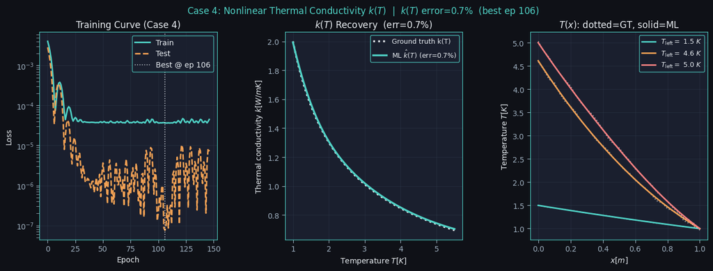

Case 4 — 훈련곡선 / $k(T)$ 복원 / $T(x)$ 프로파일

가운데 패널이 핵심이다. 점선이 정답 $k(T)$, 실선이 학습된 네트워크 — 온도 1–5 K 전 구간에서 겹친다.

## 2C.2 로그 해부

```
 Epoch |        Train |         Test |     Time
     0 |   4.0241e-03 |   2.8463e-03 |    2.1s
    30 |   4.3782e-05 |   2.6380e-06 |   38.7s
    60 |   3.7371e-05 |   3.4483e-07 |   76.5s
    90 |   4.4679e-05 |   5.3522e-06 |  114.4s
   120 |   3.6426e-05 |   5.1396e-06 |  153.1s
Early stop @ ep 146

Time: 187.1s | Best epoch: 106
k(T) mean relative error: 0.7%
```

**0 → 30 에폭에서 손실이 약 100배 떨어진다.** 대부분의 학습이 초반 30에폭에 끝나고, 이후는 미세조정이다. best epoch 106, 조기종료 146.

에폭당 약 1.3초 — 42회의 PDE 풀이가 이 시간에 들어간다. 217 dof짜리 문제이기에 가능한 속도다.

## 2C.3 test 손실이 train보다 낮은 현상

최적 시점에서 **train $3.6\times10^{-5}$ vs test $7.6\times10^{-8}$** — test가 세 자리 낮다. 과적합의 반대다.

이유는 데이터 구성에 있다:

- **train 16개** = LC_A 10 + **LC_B 6** (f≠0, 비단조 $T$)
- **test 10개** = LC_A 6 + LC_B 4

비율이 비슷하므로 구성 탓만은 아니다. 더 직접적인 이유는 **train 데이터에만 잡음이 섞여 있다는 점**이다:

```python
train_data.append((T_lv, 0., T_c + noise_std*np.std(T_c)*np.random.randn(N_dof)))
test_data.append((T_lv, 0., solve_gt(T_lv, f0=0.)))     # 잡음 없음
```

train 손실은 잡음 바닥(2% 표준편차) 아래로 내려갈 수 없지만, test는 깨끗한 정답과 비교하므로 모델이 정확해질수록 계속 떨어진다. **train 손실의 정체는 학습이 멈춘 것이 아니라 잡음 한계에 도달한 것**이다.

# Part 3. Case 1 — 비선형 구성법칙 $E(I_1)$

## 3-A. 물리와 수학 (4장)

## 3A.1 문제 설정 — 🧪

**PDE**: $\nabla\cdot\sigma = 0$, $\quad\varepsilon = \tfrac12(\nabla u + \nabla u^\top)$

**구성법칙**: $\sigma = \lambda(I_1)\,\mathrm{tr}(\varepsilon)\,I + 2\mu(I_1)\,\varepsilon$, $\quad I_1 = \mathrm{tr}(\varepsilon)$

**정답**: $E(I_1) = E_0/(1+c_2|I_1|)$, $E_0=1$ GPa, $c_2=150$, $\nu=0.3$ — 변형이 커질수록 강성이 떨어지는 **연화(softening)** 거동

Case 4와의 차이는 규모다:

|  | Case 4 | Case 1 |
| --- | --- | --- |
| 미지수 | 스칼라 $T$ | **벡터 $u$** (CG2) |
| 학습 대상 입력 | $T$ (해 자체) | **$I_1$** (해의 미분) |
| tangent 보정항 | 1개 | **2개**, 하나는 비대칭 |
| 하중 케이스 | 1개 형상 | **2개 독립 형상** |

“학습 대상이 해의 **미분**에 의존한다”는 점이 tangent를 복잡하게 만드는 근본 원인이다.

## 3A.2 왜 네트워크가 하나인가 — 구조에 의한 보장 — 🧪

등방 선형탄성에서 $\nu$가 상수이면:

$$\frac{\lambda(I_1)}{\mu(I_1)} = \frac{2\nu}{1-2\nu} = 1.5 \qquad(\nu=0.3,\ \text{항등적으로})$$

$\lambda$와 $\mu$는 독립이 아니다. 독립 함수는 **하나**뿐이므로, $\lambda$-net과 $\mu$-net을 따로 두면 서로 모순되는 값을 배울 자유도만 생긴다.

```python
_dlam_dE = nu / ((1+nu)*(1-2*nu))    # 0.5769
_dmu_dE  = 1.0 / (2*(1+nu))          # 0.3846

def get_lam_mu(self, I1_t):
    E_t = self.get_E(I1_t)
    return E_t * _dlam_dE, E_t * _dmu_dE
```

$E$ 하나만 배우고 두 상수를 곱한다. 결과의 `λ/μ = 1.5000 ± 0.0000`은 **학습 성과가 아니라 산술적 항등식**이다.

이것이 FEML 논문 §3.1.2의 “대칭 보존(symmetry-preserving) 구성” 정신 — 임의의 사상을 배우게 두지 말고, 물리적으로 허용되는 부분공간으로 가설공간을 좁혀 데이터 효율과 식별성을 얻는다. 논문은 $\lambda(I_1)$, $\mu(I_1)$ 두 MLP를 썼는데, 이 노트북은 한 걸음 더 나아가 하나로 묶었다.

## 3A.3 Newton tangent 세 항 — 🧪

잔차 $F(u) = \int\big[\lambda(I_1)\,\mathrm{tr}(\varepsilon)\,I : \varepsilon(v) + 2\mu(I_1)\,\varepsilon : \varepsilon(v)\big]dx - L(v)$

$u$로 미분하면 $\lambda,\mu$가 $I_1(u)$를 통해 $u$에 의존하므로 세 항이 나온다:

```python
a_f  = fem.form((lam_f*tr_du*inner(I2,eps_v) + 2*mu_f*inner(eps_du,eps_v))*dx_)
a_cA = fem.form((dlam_f*I1_f*tr_du*inner(I2,eps_v)
                 + 2*dmu_f*I1_f*inner(eps_du,eps_v))*dx_)
a_cB = fem.form((dlam_f*tr_du*inner(eps_fn,eps_v)
                 + 2*dmu_f*inner(eps_du,eps_fn)*inner(I2,eps_v))*dx_)
```

- **$K_{std}$** — $\lambda,\mu$ 고정 시의 강성행렬. 대칭.
- **$K_A$** — 계수 변화가 **현재 $I_1$**을 통해 기여하는 항.
- **$K_B$** — 계수 변화가 **현재 변형률 텐서 $\varepsilon$**을 통해 기여하는 항.

## 3A.4 $K_B$가 비대칭인 이유, 그리고 그 결과 — 🧪⚙️

$K_B$의 두 항을 보면 시험함수 $v$와 시행함수 $du$가 **구조적으로 다른 자리**에 들어간다:

$$\int \frac{d\lambda}{dI_1}\,\mathrm{tr}(\varepsilon(du))\;\big(\varepsilon^{sol}\!:\!\varepsilon(v)\big)\,dx$$

$du$는 트레이스로, $v$는 현재 해 $\varepsilon^{sol}$과의 내적으로 들어간다. 둘을 바꾸면 다른 값이 나온다 → **$K_B \ne K_B^\top$**.

**실무적 귀결**: $K_T$ 전체가 비대칭이므로 adjoint 방정식 $K_T^\top\psi = \partial J/\partial u$ 를 풀 때 **$K_T$를 그대로 쓸 수 없다**. 대칭이었다면 `solve`로 충분했겠지만, 여기서는 전치가 진짜로 다른 행렬이다.

```python
ksp.solveTranspose(b_adj, psi_v)
```

PETSc의 `solveTranspose`는 이미 만들어진 LU 분해를 **재사용해서** 전치계를 푼다 — 행렬을 명시적으로 전치해 다시 분해하지 않는다. 비용이 거의 들지 않는다.

## 3A.5 두 하중 케이스의 역할 — 🧪

|  | LC1: 3점 굽힘 | LC2: 단순전단 |
| --- | --- | --- |
| 형상 | 200×5 mm 빔, 24×4 | 5×5 mm 블록, 8×8 |
| 하중 | 중앙 상단 패치 $F$ | 상단 $u_x = d$ 규정 |
| $I_1$ 범위 | 0 ~ 0.0076 | 0 ~ 0.0159 |
| 손실 가중 | (0.60, 0.20, 0.20) | (0.05, 0.05, **0.90**) |

굽힘은 $\varepsilon_{xx}$가 지배적이라 $\lambda$ 결합을 잘 프로브하고, 전단은 $\varepsilon_{xy}$가 지배적이라 $\mu$를 직접 프로브한다. 가중치가 그 사실을 반영한다.

**Case 4의 $f(x)$와 같은 논리다** — 하나의 하중만으로는 $E(I_1)$의 넓은 구간을 독립적으로 제약하지 못한다. 서로 다른 변형 모드를 섞어 관측 축을 늘린 것이다. 두 케이스를 합쳐 $I_1$ 학습 범위 0.016을 덮는다.

## 3-B. 데이터 생성 (Cell 7a, 3장)

## 3B.1 두 독립 FEM 시스템 — ⚙️

```python
domain_b = dmesh.create_rectangle(..., [[0.,0.],[L_b,H_b]], [24,4], ...)   # 빔
domain_s = dmesh.create_rectangle(..., [[0.,0.],[L_s,H_s]], [8,8], ...)    # 전단 블록
V_b = fem.functionspace(domain_b, ('CG',2,(2,)))   # 벡터 CG2
Q_b = fem.functionspace(domain_b, quadrature_element(..., degree=4))
```

- **CG2 벡터 요소** — 변형률이 관측량이므로 변위를 2차로 잡아 변형률이 1차가 되게 한다. CG1이면 변형률이 요소별 상수라 관측 정보가 너무 거칠다.
- **$N_{qp}$**: 빔 1152, 전단 768. 이 숫자가 곧 관측 벡터의 길이다.
- 두 시스템은 **완전히 독립적으로** 생성된다. 코드 주석이 밝히듯, 과거에 시스템을 공유했다가 한쪽 상태가 다른 쪽을 오염시키는 문제가 있었다.

## 3B.2 경계조건 구성 — ⚙️

3점 굽힘은 정정(statically determinate) 조건을 정확히 재현해야 한다:

```python
def make_bcs_b():
    sw = patch_half
    bc0 = ... # 왼쪽 하단: u = (0,0)           — 핀
    bc1 = ... # 오른쪽 하단: u_y = 0           — 롤러
    bc2 = ... # 중앙 하단: u_x = 0             — 대칭
    return [bc0, bc1, bc2]
```

`locate_dofs_geometrical`에 `np.logical_and`로 두 조건(x 범위 AND y 위치)을 조합해 특정 모서리 영역만 집는다. 하중은 중앙 상단 패치에 분포시킨다:

```python
patch_len_b = assemble_scalar(fem.form(Constant(domain_b, 1.) * ds_b))
L_bf = fem.form(-_Fb/patch_len_b * _v_b[1] * ds_b)
```

패치 길이를 **적분으로 실측해서** 나눈다 — 격자를 바꿔도 총 하중 $F$가 보존된다. 점하중을 쓰면 CG2에서 응력 특이점이 생겨 학습을 오염시킨다.

## 3B.3 데이터 생성과 발산 가드 — ⚙️

```python
def picard_b(F_val, tol=1e-7, max_it=25, alpha=0.5):
    for _ in range(max_it):
        eps = get_strain_b(u_b); I1 = eps[:,0]+eps[:,1]
        if np.max(np.abs(I1)) > 0.08: return None, None    # 발산 가드
        _lam_b.x.array[:] = lam_gt(I1); _mu_b.x.array[:] = mu_gt(I1)
        ...
        u_upd = u_b.x.array + alpha*(u_new.getArray()-u_b.x.array)   # α=0.5 완화
```

- **$\alpha=0.5$ 완화** — 연화 법칙은 양의 되먹임을 가진다(변형↑ → 강성↓ → 변형↑). 완화 없이는 진동한다.
- **`|I1| > 0.08` 가드** — 발산 궤도에 들어서면 즉시 `None`을 반환해 포기한다. 호출부는 이 샘플을 건너뛴다. 학습 중 발산한 순전파가 그래디언트를 오염시키는 것을 막는 1차 방어선이다.

잡음은 변형률 표준편차의 0.2%로 주입한다(Case 4의 2%보다 훨씬 작다 — 변형률이 이미 매우 작은 값이기 때문).

## 3-C. 학습 (Cell 7b, 8장)

## 3C.1 `make_fem_system` — 폼 사전조립 — ⚙️

```python
def make_fem_system(domain):
    V = fem.functionspace(domain, ('CG',2,(2,)))
    Q = fem.functionspace(domain, quadrature_element(...))
    lam_f, mu_f, dlam_f, dmu_f, I1_f = (fem.Function(Q) for _ in range(5))
    ...
    a_f  = fem.form(...)    # K_std
    a_cA = fem.form(...)    # K_A
    a_cB = fem.form(...)    # K_B
    axx  = fem.form(r_fn*sym(grad(v))[0,0]*dx_)   # adjoint RHS용
    ayy  = fem.form(...); axy = fem.form(...)
    return dict(domain=domain, V=V, Q=Q, lam=lam_f, ..., a=a_f, cA=a_cA, cB=a_cB, ...)
```

**폼 6개를 한 번만 컴파일**하고 딕셔너리로 묶어 반환한다. 계수 `Function`들은 매 반복 `.x.array[:]`로 값만 바꾼다.

이게 필수적인 이유: 학습이 2000 에폭 × 20 샘플 × Picard 12회 = **최대 48만 번의 조립**을 요구한다. 매번 `fem.form()`을 호출하면 FFCx JIT 컴파일이 반복되어 계산이 불가능해진다.

## 3C.2 Picard 순전파, Newton tangent는 adjoint 전용 — ⚙️

```python
def picard_solve(sys, L_load, bcs_fn, tol=1e-7, max_it=12, alpha=0.5):
    ...  # K_std만 조립해서 반복
    return sys['u'].x.array.copy(), get_strain(sys), K_std, bcs

def get_K_newton(sys, K_std, bcs):
    KA = ...; KB = ...
    K_std.axpy(1.0, KA, ...); K_std.axpy(1.0, KB, ...)
    return K_std
```

**흥미로운 분업이다.** 순전파는 Picard(단순·안정)로 풀고, **수렴한 뒤에** Newton tangent 두 항을 추가로 조립해 adjoint에만 쓴다.

정당화: adjoint가 요구하는 것은 “수렴점에서의 정확한 $\partial F/\partial u$”이지, 거기 도달하는 경로가 아니다. Picard로 수렴만 시켜놓으면 tangent는 그 점에서 한 번 조립하면 된다.

Case 4는 순전파도 Newton이었다 — 스칼라 문제라 tangent가 싸기 때문. Case 1은 tangent 조립이 비싸므로 반복마다 하지 않는다.

**주의**: `get_K_newton`은 `K_std`를 **파괴적으로 갱신**한다(`axpy`). 호출 후 `K_std`는 더 이상 $K_{std}$가 아니라 $K_T$다. 재사용하려면 복사해 두어야 한다.

## 3C.3 손실 정의와 하중케이스별 정규화 — ⚙️

$$J = w_{xx}\frac{\|\varepsilon_{xx}-\varepsilon_{xx}^{obs}\|^2}{\|\varepsilon_{xx}^{obs}\|^2}
+ w_{yy}\frac{\|\cdot\|^2}{\|\cdot\|^2} + w_{xy}\frac{\|\cdot\|^2}{\|\cdot\|^2}$$

```python
n_xx = max(float(np.dot(eps_obs[:,0], eps_obs[:,0])), 1e-30)
J_val = (w_xx*float(np.dot(r_xx,r_xx))/n_xx + ...)
```

**성분마다 따로 정규화**하는 것이 핵심이다. 굽힘에서 $\varepsilon_{xx}$는 $\varepsilon_{xy}$보다 자릿수가 크므로, 정규화 없이 합치면 작은 성분이 손실에 전혀 기여하지 못한다.

가중치 `W_BEND=(0.6,0.2,0.2)` / `W_SHEAR=(0.05,0.05,0.9)`는 각 하중케이스에서 **정보량이 많은 성분**에 비중을 준다.

## 3C.4 adjoint RHS 조립 — ⚙️

Case 4는 관측이 절점 온도라 RHS가 곧 잔차 벡터였다. 여기서는 관측이 **적분점 변형률**이므로 한 단계가 더 필요하다:

```python
def _adj(form, w, r, n):
    sys['r'].x.array[:] = -2.*w*r/n      # 적분점 잔차를 계수 Function에 담고
    bv = fem_petsc.assemble_vector(form)  # ∫ r * sym(grad(v))[i,j] dx 를 조립
    return bv

b_adj = _adj(sys['axx'], w_xx, r_xx, n_xx)
b_adj.array[:] += b_yy.array[:] + b_xy.array[:]
```

$\partial J/\partial u$는 **절점 벡터**여야 하는데 잔차는 적분점에 있다. 그래서 `∫ r · ε(v) dx` 형태로 조립해 시험함수를 통해 절점으로 내린다. 이것이 변형률 관측에 대응하는 adjoint 소스항이다.

## 3C.5 VJP 연쇄법칙 — ⚙️

```python
eps_psi = get_strain(sys, sys['psi'])          # adjoint 해의 "변형률"
I1_arr  = eps_arr[:,0]+eps_arr[:,1]
I1_psi  = eps_psi[:,0]+eps_psi[:,1]

dJdlam_np = I1_arr * I1_psi / N_qp
dJdmu_np  = 2.*(eps_arr[:,0]*eps_psi[:,0] + eps_arr[:,1]*eps_psi[:,1]
              + 2.*eps_arr[:,2]*eps_psi[:,2]) / N_qp

dJdE_np = dJdlam_np * _dlam_dE + dJdmu_np * _dmu_dE     # 연쇄법칙
E_t = cs_model.get_E(I1_t)
E_t.backward(torch.tensor(dJdE_np).unsqueeze(-1))
```

구조가 Case 4와 **정확히 같다** — 잔차의 계수 의존 항에 해와 adjoint를 대입한 것이다. $\lambda$ 항이 $\mathrm{tr}(\varepsilon)\,\mathrm{tr}(\varepsilon(\psi))$, $\mu$ 항이 $2\,\varepsilon:\varepsilon(\psi)$ 형태로 나온다(전단 성분의 계수 2는 텐서 대칭성에서 온다).

마지막 줄이 §3A.2의 단일 네트워크 설계와 짝을 이룬다 — $\lambda,\mu$에 대한 두 미분을 **상수 두 개**로 $E$ 하나에 합류시킨다.

## 3C.6 훈련 안정화 3중 방어 — ⚙️

```python
# ① gradient clipping
torch.nn.utils.clip_grad_norm_(cs_model.parameters(), max_norm=0.5)

# ② step skip — 최근 10에폭 최소의 5배를 넘으면 이번 업데이트 폐기
_rmin = min(train_losses[-10:]) if len(train_losses)>=10 else float("inf")
if _cur < 5.0 * _rmin or len(train_losses) < 10:
    optimizer.step()
else:
    optimizer.zero_grad()

# ③ rollback — test 손실이 최적의 5배를 넘으면 최적 가중치 복원 + LR 절반
if is_spike:
    cs_model.load_state_dict(best_state)
    new_lr = max(optimizer.param_groups[0]['lr']*0.5, 1e-5)
    optimizer = torch.optim.Adam(cs_model.parameters(), lr=new_lr)
```

**왜 세 겹이나 필요한가** — 이 학습에서는 한 번의 나쁜 업데이트가 단순히 손실을 올리는 데 그치지 않는다. $E$가 잘못된 방향으로 크게 움직이면 다음 순전파에서 **Picard가 발산**하고(§3B.3의 가드에 걸려 샘플이 통째로 버려짐), 그러면 그래디언트 정보 자체를 잃는다.

①은 크기를 제한, ②는 나쁜 스텝을 사전 차단, ③은 이미 망가진 뒤의 복구다. 실행 로그에 rollback이 **4회**(ep 1358, 1360, 1514, 1673) 기록되었고, 그때마다 LR이 절반씩 줄며 학습이 계속됐다.

## 3C.7 옵티마이저 설정 — ⚙️

```python
optimizer = torch.optim.Adam(cs_model.parameters(), lr=1e-3, betas=(0.9, 0.99))
scheduler = CosineAnnealingWarmRestarts(optimizer, T_0=300, T_mult=2, eta_min=1e-5)
n_epochs = 2000; patience_es = 200
```

- **$\beta_2=0.99$** (기본 0.999) — 2차 모멘트의 기억을 짧게 만든다. 위에서 본 “가끔 터지는 그래디언트”를 빨리 잊게 하려는 의도다.
- **CosineAnnealingWarmRestarts** — 300, 900, 2100 에폭에서 LR을 재시동한다. 정체 구간을 능동적으로 빠져나오기 위한 것이다.
- **인내 200 에폭** — Case 4(40)보다 훨씬 길다. 이 문제가 그만큼 느리고 불안정하게 수렴한다는 뜻이다.

## 3C.8 full-batch인 이유 — ⚙️

```python
# Full-batch: all samples per epoch (mini-batch fails for FEM adjoint)
```

각 샘플의 그래디언트가 `.grad`에 **누적**된 뒤 에폭 끝에 한 번 `step()`한다. 미니배치를 쓰지 않는 이유:

- 샘플 하나가 곧 PDE 풀이 하나 + adjoint 하나다. 배치를 나눠도 계산량이 줄지 않는다.
- 하중케이스별로 손실 스케일과 가중치가 다르므로, 배치를 섞으면 업데이트 방향이 하중케이스에 따라 크게 요동친다.
- §3C.6의 step-skip 판정이 **에폭 단위 손실**을 기준으로 하는데, 미니배치면 그 기준 자체가 잡음투성이가 된다.

## 3-D. 결과 (2장)

## 3D.1 결과 그림

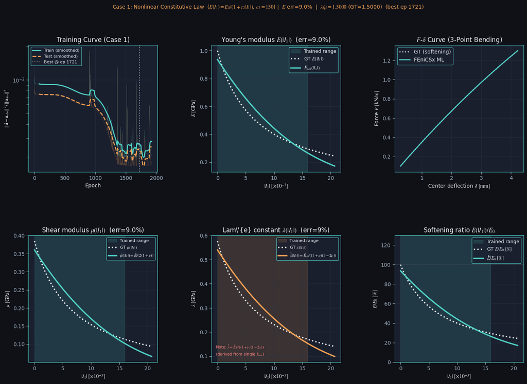

Case 1 — 훈련곡선 / $E(I_1)$ / $F$-$\delta$ / $\mu$ / $\lambda$ / 연화비

음영 구간이 학습된 $I_1$ 범위(0 ~ 0.016)다. 그 안에서 $E(I_1)$이 정답을 따라가고, 밖으로 나가면 외삽이므로 신뢰할 수 없다.

## 3D.2 실제 출력값

```
Time: 8665.6s | Best ep: 1721 | Rollbacks: 4
E   error: 9.0%   (primary metric)
mu  error: 9.0%   (= E error, same network)
lam error: 9.0%   (= E error, same network)
lam/mu ratio: mean=1.5000  std=0.0000  (GT=1.5000)
```

| 항목 | 값 |
| --- | --- |
| $E$ 오차 (학습 범위 내) | **9.0%** |
| $\lambda/\mu$ | 1.5000 ± 0.0000 (구조적 보장, §3A.2) |
| best epoch | 1721 / 2000 |
| rollback | 4회 |
| 총 시간 | **8,666초 ≈ 2.4시간** |

Case 4(0.7%)보다 한 자릿수 나쁘다. 원인 후보: 관측이 해의 **미분**(변형률)이라 정보가 한 단계 희석되고, tangent가 복잡해 adjoint 오차 여지가 크며, 두 하중케이스의 손실 스케일 비대칭이 학습을 불안정하게 만든다.

# Part 4. 공통 아키텍처 정리

## 4.1 adjoint 뼈대 — 두 Case가 공유하는 5단계

```
┌─ ① 순전파 ────────────────────────────────────────────┐
│  NN이 closure 값을 quadrature 배열로 뱉음              │
│  → fem.Function.x.array[:] 에 대입                     │
│  → Picard 또는 Newton으로 PDE 풀이                     │
│  → 수렴점에서 정확한 tangent K_T 조립                  │
└───────────────────────────────────────────────────────┘
                        ↓  u_sol, K_T
┌─ ② 손실 미분 ────────────────────────────────────────┐
│  ∂J/∂u 를 절점 벡터로 (관측이 적분점이면 조립 필요)   │
│  BC dof는 0으로                                        │
└───────────────────────────────────────────────────────┘
                        ↓  b_adj
┌─ ③ adjoint 풀이 ─────────────────────────────────────┐
│  ksp.solveTranspose(b_adj, psi)   →   K_T^T ψ = ∂J/∂u │
│  (LU 분해 재사용, 파라미터 개수와 무관하게 1회)        │
└───────────────────────────────────────────────────────┘
                        ↓  ψ
┌─ ④ VJP 조립 ─────────────────────────────────────────┐
│  ∂J/∂(closure) = 잔차의 계수 의존항에 해와 ψ 대입     │
│  Case 4: ∇T·∇ψ                                        │
│  Case 1: tr(ε)tr(ε_ψ), 2ε:ε_ψ → 연쇄법칙으로 ∂J/∂E   │
└───────────────────────────────────────────────────────┘
                        ↓  numpy 배열 (길이 = N_qp)
┌─ ⑤ PyTorch 역전파 ───────────────────────────────────┐
│  out = model(input_qp)                                 │
│  out.backward(dJd_closure)      → .grad 누적           │
└───────────────────────────────────────────────────────┘
```

**두 프레임워크 사이를 오가는 것은 numpy 배열 두 개뿐**이다 — 내려가는 closure 값, 올라오는 VJP.

## 4.2 pyadjoint 없이 되는 이유

$$\frac{dJ}{d\theta} = \psi^\top\Big(-\frac{\partial F}{\partial g}\Big)\frac{\partial g}{\partial\theta},
\qquad K_T^\top\psi = \frac{\partial J}{\partial u}$$

이 식이 요구하는 것은 세 가지뿐이다:

| 필요한 것 | 어디서 오는가 |
| --- | --- |
| $K_T$ | **Newton이 이미 조립해 갖고 있다** |
| $K_T^\top$ 풀이 | PETSc `solveTranspose` (분해 재사용) |
| $\partial F/\partial g$ | 잔차의 계수 항에서 **손으로 유도** (한 줄짜리 폼) |

pyadjoint는 이 과정을 자동화·일반화해 주지만, **정상상태 단일 PDE에서는 손으로 쓰는 편이 오히려 짧다**. 대신 잔차 구조가 바뀔 때마다 ④를 다시 유도해야 한다는 유지보수 비용이 생긴다.

## 4.3 `dolfinx-external-operator`의 위치

설치되고 import되지만, **실제 계산 경로에서는 호출되지 않는다.**

```python
from dolfinx_external_operator import (
    FEMExternalOperator, evaluate_operands, replace_external_operators)
```

동작하는 경로는 훨씬 단순하다 — quadrature 공간 `fem.Function`에 numpy 배열을 직접 대입하는 것.

이 패키지가 원래 해주는 일은 두 가지인데, 이 노트북은 첫 번째만 우회했다:

|  | external-operator가 해주는 것 | 이 노트북 |
| --- | --- | --- |
| **값 전달** | 외부 함수를 UFL 폼의 항으로 등록 | quadrature Function에 직접 대입 ✅ |
| **미분 자동화** | `ufl.derivative`가 그 연산자를 **경유하는 연쇄법칙 항**까지 자동 생성 | **손으로 유도**: `J_corr_form`, `a_cA`, `a_cB` |

즉 값은 numpy로 해결했고, **대가는 tangent 보정항을 직접 유도·조립하는 것**으로 치렀다. Case 4는 1항(`K_corr`), Case 1은 2항(`K_A`, `K_B`, 하나는 비대칭)이었다 — 문제가 복잡해질수록 이 부담이 빠르게 커진다.

adjoint 쪽은 external-operator가 있어도 어차피 직접 짜야 한다. 그건 UFL이 아니라 최적화 문제의 영역이다.

## 4.4 계산 비용 구조

|  | Case 4 | Case 1 |
| --- | --- | --- |
| 문제 크기 | 217 dof / 2160 qp | 1152 + 768 qp |
| 에폭당 PDE 풀이 | 16 train + 10 test = 26 | 20 train + 10 test = 30 |
| 에폭당 adjoint | 16 | 20 |
| 에폭당 시간 | ~1.3 s | **~4.3 s** |
| 총 에폭 | 146 (조기종료) | 1,921 (조기종료) |
| **총 시간** | **187 s** | **8,666 s (2.4 h)** |

Part 6.12에서 이 공식에 PEMFC 숫자를 대입한다.

# Part 5. 읽으면서 확인이 필요해 보인 지점

## 5.1 결과 그림의 F–δ 패널

Cell 7b 끝부분의 F–δ 곡선 생성 부분이다:

```python
for F_v in F_dense:
    _Fb.value = F_v
    rg = picard_solve(sys_b, L_bf, make_bcs_b)      # → defl_gt
    defl_gt.append(...)
for F_v in F_dense:
    _Fb.value = F_v
    rm = picard_solve(sys_b, L_bf, make_bcs_b)      # → defl_ml
    defl_ml.append(...)
```

두 루프가 같은 함수를 같은 인자로 호출한다. `picard_solve`는 내부에서 `update_lame` → `cs_model.get_lam_mu_dI1`을 부르므로 **양쪽 모두 학습된 모델**을 쓴다.

GT 곡선으로 쓰려면 첫 루프에서 계수를 `lame_true`로 채우는 경로가 필요해 보인다. 결과 그림에서 두 곡선이 완전히 겹치는 것은 이 때문일 가능성이 있다 — 다른 패널들($E(I_1)$, $\mu$, $\lambda$)은 `lame_true`를 제대로 호출하고 있어 영향받지 않는다.

## 5.2 rollback 판정 시점

```python
tl_train = epoch_train / n_valid; train_losses.append(tl_train)

is_spike = (best_state is not None and len(test_losses) >= 2 and
            tl > best_test * SPIKE_RATIO)          # ← tl 참조
...
# (test 평가 블록)
tl = epoch_test / max(n_tv, 1); test_losses.append(tl)    # ← tl 할당
```

`tl`이 할당되기 **전에** 참조되므로, 판정은 직전 에폭의 test 손실을 본다. 에폭 0에서는 `best_state is not None`의 단락평가 덕에 오류가 나지 않는다.

**실제 영향은 크지 않아 보인다** — 로그를 보면 rollback이 4회 정상 작동했고, 스파이크가 한 에폭 늦게 감지될 뿐이다. 다만 `is_spike` 블록을 test 평가 뒤로 옮기면 의도대로 동작한다.

## 5.3 마크다운 셀과 실행 결과의 차이

마크다운 셀의 숫자 일부가 저장된 실행 출력과 다르다:

| 항목 | 마크다운 | 실행 출력 |
| --- | --- | --- |
| Case 1 $E$ 오차 | 9.9% | **9.0%** |
| Case 1 best epoch | 1813 | **1721** |
| Case 1 rollback | 3회 (ep 1567, 1569, 1701) | **4회** (ep 1358, 1360, 1514, 1673) |
| Case 4 소요시간 | 220 s | **187.1 s** |

이 슬라이드는 전부 **실행 출력값** 기준으로 작성했다. 결론(0.7% / 9.0% / λ/μ 정확)에는 영향이 없다.

## 5.4 데이터 범위 변경이 재실행되지 않음

Cell 7a의 학습 데이터 범위가 넓혀진 상태다:

```python
F_bend_train = np.logspace(np.log10(200.), np.log10(2000.), 20)   # 이전: 1200까지 10점
exy_train    = np.logspace(np.log10(0.001), np.log10(0.010), 20)  # 이전: 0.005까지 10점
```

그런데 **Cell 7a와 7b에 저장된 출력이 없다** — 넓힌 범위로는 아직 학습이 돌지 않았다. 결과 플롯(Cell 8)이 보여주는 9.0%·1721 에폭은 디스크에 남아 있던 **이전 설정의 결과**를 다시 읽어 그린 것이다.

마크다운의 “LC1 10 train, F ∈ [200,1200]”, “LC2 max |I₁| = 0.0159”, “I₁_train_max = 0.016”은 **이전 설정 기준으로는 정확**하다. 재실행하면 $I_1$ 범위가 넓어지므로 이 숫자들과 오차값이 모두 달라진다.

## 5.5 예고된 Case 5는 아직 없다

요약 셀이 다음 단계를 명시한다:

> **Next step: Case 5 — Brazilian Disc (zero-shot transfer)** Apply trained E_net to a **new geometry** (circular disc, diametral compression) without retraining. Tests whether E_net has learned the constitutive law (geometry-independent) vs. the beam geometry (not transferable).

이것이 FEML 논문의 가장 중요한 주장(§1.2.3, 2D 압축시험 → 3D 비틀림판 전이, 상대오차 ~0.1%)에 대응한다. **학습된 것이 진짜 구성법칙인지, 아니면 빔 형상에 특화된 무언가인지**를 가르는 시험이다.

`cs_model.pt`가 저장되어 있으므로 재학습 없이 새 형상에 얹기만 하면 된다. 현재 노트북은 여기까지 오지 않았고, 이 검증 없이는 “구성법칙을 배웠다”는 주장이 아직 미완이다.

# Part 6. PEMFC 코드로의 이식 설계

## 6.1 왜 이 파트가 존재하는가

PEMFC 슬라이드 §5C에서 “FEniCSx에는 Firedrake의 adjoint 인프라에 대응하는 성숙한 경로가 없어, 잔차 안의 학습 연산자를 PyTorch로 되돌리는 다리를 직접 만들어야 한다”는 것을 **실질적 관문**으로 지목했다.

**이 노트북이 그 관문을 통과한 실물이다.** 따라서 이 파트의 질문은 “가능한가”가 아니라 **“무엇을 그대로 가져오고, 무엇을 새로 만들어야 하는가”**이다.

기준선이 되는 숫자 하나를 미리 잡아두자 — Case 1이 **작은 2D 문제로 2.4시간**이 걸렸다. PEMFC는 순전파 한 번이 48분이다. 설계의 대부분이 이 격차를 다루는 일이 된다.

## 6.2 대응표 — 두 Case ↔︎ PEMFC의 미지 closure

|  | Case 4 | Case 1 | PEMFC 후보 |
| --- | --- | --- | --- |
| 학습 대상 | $k(T)$ | $E(I_1)$ | $D_{eff}(s)$, $dJ/ds$, $n_{corey}$ |
| 입력 | 해 자체 | 해의 미분 | **해의 함수** $s(C_w)$ |
| 출력 | 스칼라 | 스칼라 (→ 텐서 계수) | 스칼라 |
| 잔차 내 위치 | 발산 연산자 계수 | 구성 텐서 | **발산 연산자 계수** |
| 관측 | 온도장 | 변형률장 | $I(\eta)$ 곡선? 필드? (§6.13) |
| 미지수 개수 | 1 | 1 (벡터) | **3 (mixed)** |

PEMFC의 미지 closure 목록은 PEMFC 슬라이드 §2.15의 “논문에 없어 통상값을 쓴 파라미터”와 정확히 겹친다: `tau_brug`(1.5 또는 1.1), Leverett 다항식 계수, `n_corey=3`, `Ea_orr`.

## 6.3 $D_{eff}(s)$가 첫 후보인 이유

$$D_{eff}^{O_2} = \rho_g\big[\varepsilon(1-s)\big]^{\tau} D_g^{O_2}
\quad\longrightarrow\quad
D_{eff}^{O_2} = \rho_g\,\mathcal G_\theta(s)\,D_g^{O_2}$$

Case 4의 $k(T)$와 **구조가 동일하다**:

- **스칼라 → 스칼라** 사상
- **발산 연산자 안의 계수**로 들어감: $\nabla\cdot(D_{eff}\nabla C)$ ↔︎ $\nabla\cdot(k\nabla T)$
- 따라서 VJP도 같은 모양: $\partial J/\partial D_{eff} = \nabla C\cdot\nabla\psi$

게다가 Case 4의 정답 법칙이 $k_r(1+\beta\Delta T/T_r)^{-\delta}$ — **지수 하나짜리 멱법칙**이고, Bruggeman도 $[\varepsilon(1-s)]^\tau$ — **지수 하나짜리 멱법칙**이다. $\delta=0.62$를 복원한 것과 $\tau$를 복원하는 것은 같은 종류의 문제다.

$\tau$는 논문에 값이 없고 이번 프로젝트가 1.5 ↔︎ 1.1로 흔들어 본 바로 그 파라미터다. **“모르는 값을 가정하는 대신 데이터에서 배운다”**는 FEML의 문제의식에 가장 잘 맞는 자리다.

## 6.4 그대로 가져오는 것 ① — adjoint 5단계 골격

§4.1의 다섯 단계는 **PDE 종류와 무관한 뼈대**다. PEMFC에서도 그대로 성립한다:

| 단계 | PEMFC에서 |
| --- | --- |
| ① 순전파 | NN이 $D_{eff}$ 배열 → 3필드 Newton 풀이 → $K_T$ 확보 |
| ② 손실 미분 | $\partial J/\partial w$ ($w$ = mixed 해 벡터) |
| ③ adjoint | `solveTranspose(K_T)` — **PEMFC의 $K_T$는 비대칭이 확실하므로 필수** |
| ④ VJP | $\nabla C_{gO_2}\cdot\nabla\psi_{CgO_2}$ (§6.8) |
| ⑤ 역전파 | `Deff_t.backward(dJdDeff)` |

특히 ③은 PEMFC에서 **더 중요하다**. Case 1의 $K_B$가 비대칭이라 `solveTranspose`가 필수였는데, PEMFC 잔차는 대류항·upwind 경계항·Tafel 경계항이 전부 비대칭 기여를 만든다. 전치를 제대로 푸는 것 외의 선택지가 없다.

## 6.5 그대로 가져오는 것 ② — quadrature Function 패턴

```python
Qe = basix.ufl.quadrature_element(domain.basix_cell(), degree=qd, value_shape=())
Q  = fem.functionspace(domain, Qe)
Deff_fn   = fem.Function(Q)
dDeff_ds_fn = fem.Function(Q)
...
Deff_fn.x.array[:]     = nn_values          # NN 출력
dDeff_ds_fn.x.array[:] = nn_derivatives     # 중심차분
```

PEMFC 코드는 현재 `Deff_O2`를 **UFL 표현식**으로 갖고 있다:

```python
Deff_O2 = rho_g_const * (eps_p * (1.0 - s)) ** tau_brug * D_O2_g
```

이걸 quadrature `Function`으로 바꾸는 것이 이식의 첫 단계다. `dx` measure에 `quadrature_degree` 메타데이터를 명시해 적분점을 일치시켜야 한다 — Case 4가 `qd_t=4`로 그렇게 했다.

## 6.6 그대로 가져오는 것 ③ — 안정화 장치

§3C.6의 3중 방어(clipping / step-skip / rollback)와 조기종료·best_state 복원은 **PEMFC에서 더 절실하다**.

Case 1의 안정화가 필요했던 이유는 “나쁜 업데이트 → Picard 발산 → 샘플 손실”이었다. PEMFC에서는 같은 연쇄가 훨씬 비싸다 — 발산한 샘플 하나가 **수십 분**을 낭비한다.

추가로 PEMFC에는 이미 자체 방어선이 있다(PEMFC 슬라이드 §3.12):

```python
def check_physical(I_now, tol=0.01, I_tol=-50.0):
    ...  # 농도 범위 위반 + 음의 전류 검출
```

이 함수가 Case 1의 `if np.max(np.abs(I1)) > 0.08: return None` 가드와 같은 역할을 한다. **순전파가 실패한 샘플을 학습에서 제외**하는 경로를 만들어두면 된다.

## 6.7 바꿔야 하는 것 ① — 단일 필드 → 3필드 mixed

두 Case 모두 미지수가 하나였다(스칼라 $T$, 벡터 $u$). PEMFC는 **mixed 공간의 3필드**다:

```python
ME = basix.ufl.mixed_element([P1e, P1e, P1e])
W  = fem.functionspace(domain, ME)
p_hat_sol, Cw_sol, CgO2_sol = ufl.split(w)
```

각 단계가 이렇게 바뀐다:

|  | 단일 필드 | PEMFC mixed |
| --- | --- | --- |
| $K_T$ | $N\times N$ | $3N\times3N$ 블록 구조 |
| $\partial J/\partial u$ | 절점 벡터 | **어느 서브필드에 넣을지 결정 필요** |
| $\psi$ | 스칼라장 | $(\psi_p, \psi_{C_w}, \psi_{CgO_2})$ 세 성분 |
| VJP | 한 항 | **관련 서브필드에서만 추출** |

**좋은 소식**: $K_T$ 자체는 이미 monolithic으로 조립되어 있으므로(PEMFC 슬라이드 §3.8) `solveTranspose`는 그대로 작동한다. 블록 구조를 신경 쓸 필요가 없다.

**주의할 점**: $\psi$를 서브필드로 분리할 때 `w.sub(i).collapse()` 패턴이 필요하고, 그 과정에서 dof 순서가 바뀌므로 VJP 조립 시 인덱싱을 맞춰야 한다.

## 6.8 바꿔야 하는 것 ② — PEMFC에서 $\partial J/\partial D_{eff}$

잔차에서 $D_{eff}$가 등장하는 항은 산소 방정식의 확산항 하나뿐이다:

```python
F_oxy = (... + Deff_O2 * ufl.inner(ufl.grad(CgO2_sol), ufl.grad(v_cgo2)) * dx + ...)
```

Case 4의 $\int k\nabla T\cdot\nabla v$와 **형태가 완전히 같다**. 따라서 VJP도 같은 유도를 따른다:

$$\frac{\partial J}{\partial D_{eff}}\bigg|_{qp} = \nabla C_g^{O_2}\cdot\nabla\psi_{CgO_2}\bigg|_{qp}$$

구현 스케치:

```python
# ψ의 산소 성분만 뽑는다
psi_cgo2 = psi_fn.sub(2).collapse()

gradC   = fem.Function(Vec_Q); gradC.interpolate(fem.Expression(grad(CgO2_sol), pts))
gradPsi = fem.Function(Vec_Q); gradPsi.interpolate(fem.Expression(grad(psi_cgo2), pts))

gC = gradC.x.array.reshape(-1,2); gP = gradPsi.x.array.reshape(-1,2)
dJdDeff = torch.tensor((gC*gP).sum(axis=1)/N_qp, dtype=torch.float64)

Deff_t = model(s_qp_tensor)
Deff_t.backward(dJdDeff)
```

**Case 4의 코드와 거의 글자 단위로 같다.** 다른 것은 `psi_fn` 대신 `psi_fn.sub(2).collapse()`를 쓴다는 점뿐이다.

## 6.9 바꿔야 하는 것 ③ — tangent 보정항은 이미 있다

§2A.2에서 Case 4가 $K_{corr}$을 손으로 유도해야 했던 이유는, `k_fn`이 UFL 입장에서 상수 계수라 $\partial k/\partial T$ 연쇄를 모르기 때문이었다.

**PEMFC는 사정이 다르다.** 현재 코드는 $s$를 필드가 아닌 **UFL 표현식**으로 갖고 있어(PEMFC 슬라이드 §3.8), UFL이 $s$ 경유 의존성을 전부 자동 미분한다:

```python
s = s_expr(Cw_sol)          # UFL 표현식 — 미분 사슬이 살아있다
Deff_O2 = rho_g_const * (eps_p * (1.0 - s)) ** tau_brug * D_O2_g
```

$D_{eff}$를 NN으로 바꾸면 그 **한 자리에서만** 사슬이 끊어진다. 따라서 손으로 채워야 할 보정항도 하나뿐이다:

$$K_{corr} = \int \frac{\partial D_{eff}}{\partial s}\,\frac{\partial s}{\partial C_w}\,\delta C_w \;\;\nabla C_g^{O_2}\cdot\nabla v\;dx$$

$\partial s/\partial C_w$는 여전히 UFL이 준다(해석적). $\partial D_{eff}/\partial s$만 NN에서 중심차분으로 뽑아 quadrature Function에 담으면 된다 — Case 4의 `dkdT_fn`과 같은 역할이다.

**즉 PEMFC의 기존 설계가 이식에 유리하게 작용한다.** 나머지 closure(Leverett, Corey, 이동도)의 사슬은 UFL이 계속 처리한다.

## 6.10 바꿔야 하는 것 ④ — VI box constraint와 활성집합

PEMFC는 `vinewtonrsls`(reduced-space active-set VI 솔버)로 $C_w, C_{gO_2} \in [0,1]$을 강제한다(PEMFC 슬라이드 §3.10). 두 Case에는 이런 제약이 없었다.

**문제**: 활성집합(제약이 걸린 dof 집합)이 $\theta$에 따라 바뀌면, 해 $w(\theta)$가 그 경계에서 **미분 가능하지 않다**. adjoint가 전제하는 매끄러움이 깨진다.

**실용적 대응 후보 세 가지:**

1. **활성집합 고정 후 축소 시스템에서 전치 풀이** — 수렴점의 활성집합을 읽어, 비활성 dof만의 부분공간에서 $K_T^\top\psi=\partial J/\partial w$를 푼다. 활성 dof의 $\psi$는 0으로 둔다. 표준적인 처리다.
2. **제약이 실제로 활성인지 먼저 확인** — 학습에 쓸 $\eta$ 구간을 flooding 붕괴 이전(예: $\eta \le 1.2$)으로 잡으면 box 제약이 거의 활성화되지 않을 수 있다. 그렇다면 문제 자체가 사라진다.
3. **학습용 순전파만 제약 없는 Newton으로** — 좁은 $\eta$ 범위에서 warm start가 좋으면 `newtonls`로도 충분할 수 있다(PEMFC 슬라이드 §3.1에서 라이브러리의 `run_case`가 실제로 그렇게 동작한다).

**②를 먼저 확인하는 것을 권한다** — 활성집합이 비어 있다면 나머지 고민이 불필요해진다.

## 6.11 바꿔야 하는 것 ⑤ — continuation과 학습 루프

PEMFC의 순전파는 단발 풀이가 아니라 $\eta=0.02$에서 목표까지 **적응 스텝 continuation**이다(PEMFC 슬라이드 §3.14). 스텝 크기가 성공/실패에 따라 이산적으로 바뀌므로, 이 경로 전체가 $\theta$에 대해 매끄럽지 않다.

**해법은 관점을 바꾸는 것이다.** continuation은 “특정 $\eta$의 해를 얻기 위한 **수단**”일 뿐, 미분 대상이 아니다. adjoint가 필요로 하는 것은 **도착점에서의 $K_T$** 하나뿐이다.

```
continuation으로 η_target까지 도달  ←  이 경로는 미분하지 않는다
                ↓
        수렴한 해 w(η_target), K_T
                ↓
        여기서부터 adjoint 5단계 시작
```

Case 1이 “Picard로 수렴시키고 수렴점에서만 Newton tangent를 조립”한 것과 **정확히 같은 논리**다(§3C.2). 경로는 자유롭게, 미분은 도착점에서만.

**추가 이득**: 이전 에폭의 해를 warm start로 재사용하면 continuation을 매번 처음부터 돌릴 필요가 없다. $\theta$가 조금씩 변하므로 해도 조금씩 변한다 — 에폭당 비용을 크게 줄일 수 있는 지점이다.

## 6.12 비용 분석 — 가장 현실적인 제약

§4.4의 공식에 PEMFC 숫자를 넣어본다:

$$\text{총 비용} \approx (\text{에폭}) \times (\text{샘플}) \times (\text{순전파} + \text{adjoint})$$

[output not shown]

**정확한 수치가 아니라 자릿수를 보는 표다.** 읽어야 할 결론은 명확하다 — **어떤 하나의 최적화로는 부족하고, 네 가지를 모두 적용해야 학습이 가능한 영역에 들어온다.**

가장 효과가 큰 것은 **warm start**다. continuation을 매 에폭 처음부터 돌리는 것과 이전 해에서 이어가는 것의 차이가 수십 배다(§6.11).

## 6.13 관측량 $J$를 무엇으로 정의할 것인가

두 Case의 관측은 명확했다 — 온도장, 변형률장. PEMFC는 선택지가 여럿이고, 이 선택이 학습 난이도를 좌우한다.

| 후보 | 정보량 | 비용 | 문제점 |
| --- | --- | --- | --- |
| **A. $I(\eta)$ 분극곡선** | 낮음 (스칼라 × 점 개수) | 낮음 | $\eta$마다 순전파 필요, 정보가 과도하게 압축됨 |
| **B. 막 위 $I_{local}(y)$ 프로파일** | 중간 (60점) | 낮음 | 논문 Fig. 11b/22b와 대응 — 검증 자료가 있다 |
| **C. $s(x,y)$ 전체 필드** | 높음 | 없음(이미 계산됨) | 실측 불가능 — 합성 데이터로만 |
| **D. $s_{max}$ 스칼라** | 매우 낮음 | 없음 | 학습 신호로는 부족 |

**B를 권한다.** Case 1의 변형률장 관측과 정보량이 비슷하고(1152 qp vs 60점은 차이가 크지만, 필드 하나를 통째로 보는 것보다 안정적), 논문이 같은 양을 제시하고 있어 **미래에 실측과 대조할 경로**가 열려 있다.

주의: PEMFC 슬라이드 §3.13에서 지적한 대로 현재 `I_ave`가 논문 Eq. 33의 경계적분이 아니라 산술평균이다. **학습 라벨로 쓰기 전에 경계적분으로 고쳐야** 한다 — 그러지 않으면 NN이 물리가 아니라 투영 오버슛을 배운다.

## 6.14 식별 가능성 — 두 Case가 준 교훈

이 노트북이 반복해서 보여준 패턴이다:

|  | 문제 | 해법 |
| --- | --- | --- |
| Case 4 | $f=0$이면 $T$가 단조 → 각 $T^*$에 방정식 하나 | **내부 열원 $f(x)$ 추가** → $T$ 비단조 → 방정식 둘 |
| Case 1 | 굽힘만으로는 $\mu$를 직접 프로브 못 함 | **단순전단 추가** → $\varepsilon_{xy}$ 지배 하중 확보 |

**두 경우 모두 네트워크를 키우거나 학습률을 조정해서 푼 것이 아니다.** 관측이 미지 함수를 유일하게 결정하도록 **실험 설계를 바꿨다**.

이것은 FEML 논문이 한계로 명시한 부분이기도 하다 — “여러 연산자·파라미터가 비슷한 관측량을 만들어낼 때 식별 불가능성이 생긴다.”

## 6.15 PEMFC의 식별성 확보 전략

PEMFC에서 이 문제는 **추상적 우려가 아니라 구체적 위험**이다. $\tau$, $dJ/ds$, $n_{corey}$가 동시에 미지인데 셋 다 같은 관측량($I$, $s$)에만 영향을 준다. 서로 다른 조합이 같은 곡선을 낼 수 있다.

**전략 A — 하나씩 고정(권장 출발점)**

$\tau$만 학습하고 나머지는 문헌값으로 고정한다. Case 4가 $k(T)$ 하나만 배운 것과 같다. 성공하면 다음을 추가한다.

**전략 B — 관측 축 늘리기**

Case 4의 $f(x)$에 대응하는 것을 PEMFC에서 찾는다. 후보:

| 축 | 근거 | 비용 |
| --- | --- | --- |
| **유입 상대습도 RH** | $C_g^{sat}$ 문턱 대비 유입 수분이 달라져 flooding 개시가 이동 | 낮음 (BC 값만 변경) |
| **압력차 $\Delta p$** | 대류 퍼지 세기가 바뀜 → $s$ 분포가 질적으로 달라짐 | 낮음 |
| **GDL 두께 $L_x$** | 논문 Fig. 21/22가 실측 스윕을 제공 | 격자 재생성 필요 |

**RH가 가장 좋은 후보다.** 건조 유입(RH=0)에서는 물이 문턱까지 쌓여야 액상이 생기고, 포화 유입(RH=1)에서는 즉시 생긴다. **같은 $s$ 값이 서로 다른 $\nabla s$와 함께 관측**되므로 — Case 4의 비단조 $T(x)$와 정확히 같은 구조다.

**전략 C — 구조적 제약**

Case 1이 $\lambda/\mu=1.5$를 구조로 못 박은 것처럼, 물리적으로 알려진 제약을 네트워크에 넣는다:

- $\mathcal G_\theta(0) = \varepsilon^\tau$ (건조 상태에서 알려진 값)
- $\mathcal G_\theta$ 단조감소 (포화도가 높을수록 확산 방해)
- $\mathcal G_\theta(s) > 0$ — Softplus 출력으로 보장 (Case 4와 동일)

## 6.16 최소 프로토타입 A — 산소 방정식 단독

**목표**: 전체 시스템 이전에 adjoint 배선이 맞는지 검증한다.

```
도메인    : PEMFC와 같은 형상, 격자는 12×30으로 축소
미지수    : Cg_O2 하나만 (p와 C_w는 미리 푼 해에서 고정)
잔차      : F_oxy만 (대류·확산·모세관·경계항 전부 유지)
학습 대상 : D_eff(s) — s는 고정된 C_w에서 계산되므로 상수장
관측      : 막 위 I_local(y) 프로파일
GT        : τ=1.5로 생성 후 잡음 주입
검증      : 학습된 G_θ(s)가 [ε(1-s)]^1.5 를 복원하는가
```

**Case 4와 거의 같은 난이도**다 — 단일 스칼라 미지수, 발산 연산자 계수 학습. 순전파가 선형에 가까우므로(다른 필드가 고정이면 $s$도 고정) 수 초 내에 끝난다.

이 단계에서 확인할 것: - `solveTranspose`가 PEMFC의 비대칭 잔차에서 올바른 $\psi$를 주는가 - VJP $\nabla C\cdot\nabla\psi$가 유한차분 그래디언트와 일치하는가 **(← 반드시 해야 할 검증)** - 잡음 하에서 $\tau=1.5$가 복원되는가

## 6.17 최소 프로토타입 B — 3필드 + 스칼라 하나

A가 통과하면 다음 단계다.

```
미지수    : p, C_w, Cg_O2 (mixed 3필드, 실제 결합)
학습 대상 : τ 하나 (신경망이 아니라 스칼라 파라미터)
η 범위    : 0.02 ~ 0.5 (flooding 스파이크 이전, 붕괴 훨씬 이전)
격자      : 12×30
관측      : I_local(y) at 3~5개 η
GT        : τ=1.5 실행 결과
검증      : 학습이 1.5로 수렴하는가
```

**핵심 설계 결정: 신경망 대신 스칼라 하나부터 시작한다.** 파라미터가 1개면 유한차분으로 그래디언트를 직접 검증할 수 있고, 식별성 문제가 원천적으로 없으며, 학습이 실패하면 원인이 adjoint 배선임이 확실해진다.

여기서 확인할 것: - mixed 공간에서 $\psi$ 서브필드 추출과 VJP 인덱싱이 맞는가 - box 제약이 이 $\eta$ 범위에서 실제로 활성화되는가 (§6.10의 ②) - warm start로 에폭당 비용이 얼마나 줄어드는가

이것까지 되면 그때 $\tau$를 $\mathcal G_\theta(s)$로 승격시킨다.

## 6.18 로드맵

```
[0] 준비    I_ave를 논문 Eq.33 경계적분으로 교체 (§6.13)
             → 라벨 품질 확보. 이거 없이는 나머지가 무의미
                        ↓
[1] 프로토A  산소 방정식 단독 + D_eff(s) 학습        (§6.16)
             ★ 유한차분 그래디언트 검증 필수
                        ↓
[2] 프로토B  3필드 + τ 스칼라 하나                   (§6.17)
             ★ box 제약 활성 여부 확인
                        ↓
[3] 확장     τ → G_θ(s) 신경망 승격
             ★ Softplus 출력 + 단조성 제약 (§6.15 C)
                        ↓
[4] 식별성   RH 축 추가로 관측 다양화                (§6.15 B)
                        ↓
[5] 전이검증 학습에 쓰지 않은 Lx·형상으로 zero-shot
             ← FEML 논문 §1.2.3, 이 노트북의 미완 Case 5 (§5.5)
```

**[0]과 [1]의 별표 두 개가 이 로드맵에서 가장 중요하다.** 라벨이 오염되어 있거나 그래디언트가 틀렸으면, 이후 단계에서 나오는 어떤 결과도 해석할 수 없다.

## 6.19 남는 한계 — 정직하게

**① 실측 데이터가 없다.** 이 노트북의 두 Case 모두 합성 데이터였다 — 알려진 법칙으로 만들고, 그 법칙을 되찾는 구조다. PEMFC도 같은 출발점에 설 수밖에 없다. 이때 배우는 것은 “진짜 물리”가 아니라 **“내가 넣은 가정을 되찾을 수 있는가”**이며, 이건 방법론 검증이지 물리 발견이 아니다.

**② 학습된 것이 진짜 closure인지 검증할 수단이 제한적이다.** FEML 논문의 답은 zero-shot 전이(§5.5)인데, 이 노트북에서도 아직 미완이다. PEMFC에서는 로드맵 [5]가 그 역할을 한다.

**③ 정상상태·등온 틀은 그대로 남는다.** 어떤 closure를 학습해도, 시간항이 없는 모델이 동적 flooding(물방울 이탈, 채널 slug)을 표현할 수는 없다. 하이브리드는 **모델 안의 빈칸을 채우는 것**이지, 모델의 틀을 넓히는 것이 아니다.

**④ 식별성이 근본적으로 해결되지 않을 수 있다.** $\tau$, $dJ/ds$, $n$이 관측에 남기는 흔적이 충분히 다르지 않다면, 관측 축을 늘려도 유일해가 나오지 않는다. 그 경우 정직한 결론은 “이 관측으로는 이만큼만 결정된다”이며, 그 자체가 의미 있는 결과다.

# 참고자료

## 참고문헌

- A. Farsi, N. Bouziani, D.A. Ham, “Missing Physics Discovery through Fully Differentiable Finite Element-Based Machine Learning,” *Research Square preprint* (2026), DOI: 10.21203/rs.3.rs-8641881/v1.
- N. Bouziani, N. Boullé, “Structure-preserving operator learning,” arXiv:2410.01065 (2024). — SPON 구조
- N. Bouziani, D.A. Ham, A. Farsi, “Differentiable programming across the PDE and Machine Learning barrier,” arXiv:2409.06085 (2024).
- 이 저장소: `FEML_FEniCSx_PSELab.ipynb`, `pemfc_lib.py`, PEMFC 슬라이드 (`PEMFC_TauLx_HighEta_Exploration.qmd`)

## 이 슬라이드가 열어둔 것

- **Case 5 (zero-shot 전이)** — 학습된 `cs_model.pt`를 새 형상에 얹는 검증. 이 노트북의 다음 단계이자, “구성법칙을 배웠다”는 주장의 최종 근거 (§5.5)
- **넓힌 데이터 범위로의 재실행** — Cell 7a의 $F_{max}$, $\varepsilon_{xy,max}$ 확장이 아직 학습에 반영되지 않음 (§5.4)
- **PEMFC 프로토타입 A** — adjoint 배선 검증. 유한차분 그래디언트 대조가 첫 관문 (§6.16)
- **$I_{ave}$ 경계적분 교체** — 학습 라벨 품질의 전제조건 (§6.13, §6.18)